# CMPINF 2130 Summer 2021 - Week 04

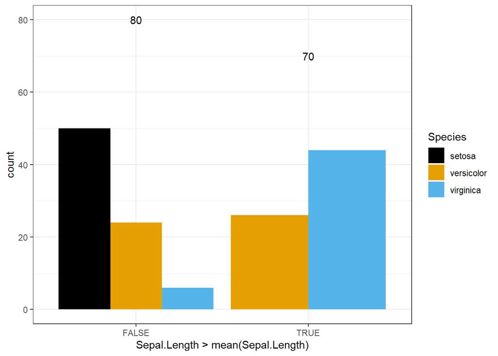

```r
iris %>%
  ggplot(mapping = aes(x = Sepal.Length > mean(Sepal.Length))) +
  geom_bar(mapping = aes(fill = Species),
           position = "dodge") +
  geom_text(stat = 'count',
            mapping = aes(label = stat(count))) +
  ggthemes::scale_fill_colorblind() +
  theme_bw()
```

We can override or instruct how to group the text via the `group` aesthetic.

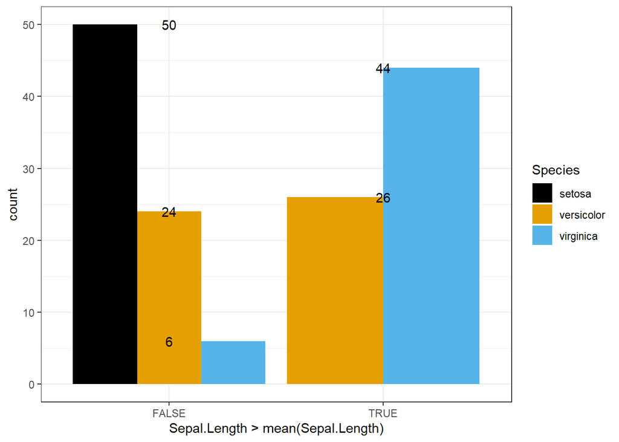

```r
iris %>%
  ggplot(mapping = aes(x = Sepal.Length > mean(Sepal.Length))) +
  geom_bar(mapping = aes(fill = Species),
           position = "dodge") +
  geom_text(stat = 'count',
            mapping = aes(group = Species,
                          label = stat(count))) +
  ggthemes::scale_fill_colorblind() +
  theme_bw()
```

Adjusting the text position is painful.

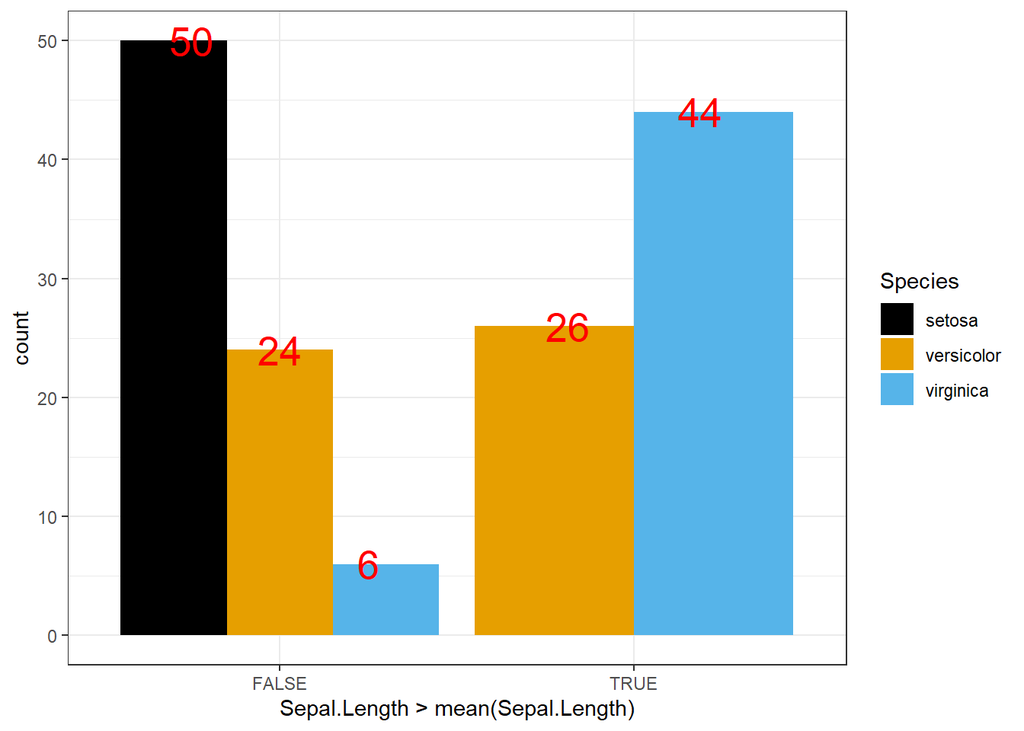

```r
iris %>%
  ggplot(mapping = aes(x = Sepal.Length > mean(Sepal.Length))) +
  geom_bar(mapping = aes(fill = Species),
           position = "dodge") +
  geom_text(stat = 'count',
            mapping = aes(group = Species,
                          label = stat(count)),
            position = position_dodge(0.75),
            color = 'red', size = 7) +
  ggthemes::scale_fill_colorblind() +
  theme_bw()
```

Let’s set the x-axis back to Species and the fill to the conditional test.

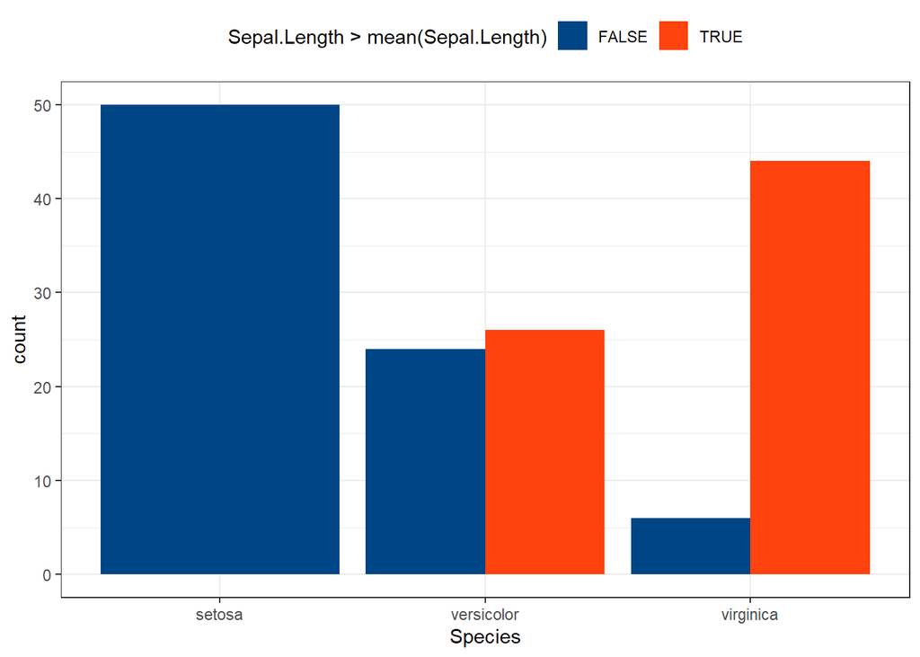

```r
iris %>%
  ggplot(mapping = aes(x = Species)) +
  geom_bar(mapping = aes(fill = Sepal.Length > mean(Sepal.Length)),
           position = "dodge") +
  ggthemes::scale_fill_calc() +
  theme_bw() +
  theme(legend.position = "top")
```

Essentially we are using the bar fill to denote the number of rows per **combination**. Combinations can also be displayed via heat maps.

A heat map is essentially a scatter plot. It consists of x position and y position BUT instead of points we will use a TILE.

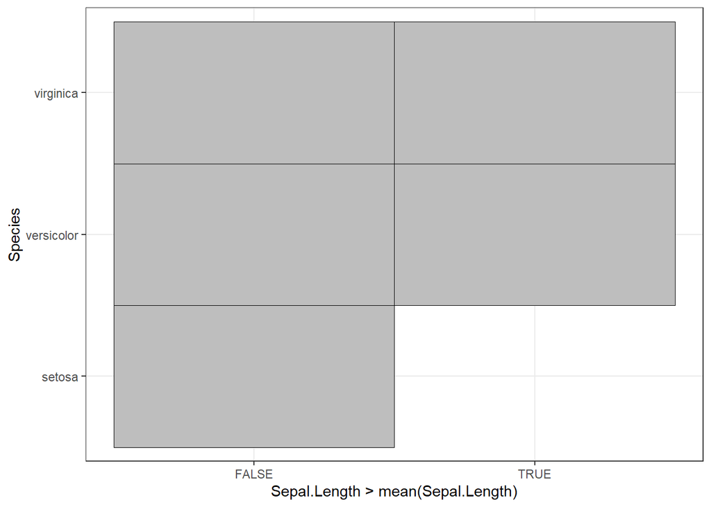

```r
iris %>%
  count(Species, Sepal.Length > mean(Sepal.Length)) %>%
  ggplot(mapping = aes(x = `Sepal.Length > mean(Sepal.Length)`,
                       y = Species)) +
  geom_tile(color = 'black', fill = 'grey') +
  theme_bw()
```

Map the number of observations to the fill of the tile.

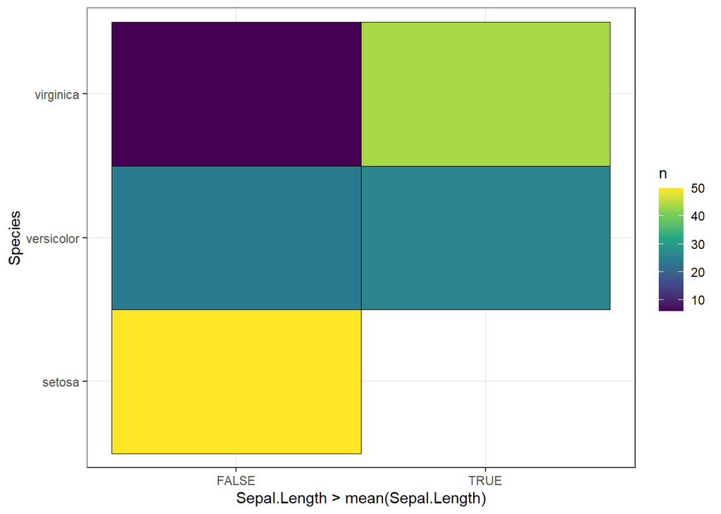

```r
iris %>%
  count(Species, Sepal.Length > mean(Sepal.Length)) %>%
  ggplot(mapping = aes(x = `Sepal.Length > mean(Sepal.Length)`,
                       y = Species)) +
  geom_tile(color = 'black',
            mapping = aes(fill = n)) +
  scale_fill_viridis_c() +
  theme_bw()
```

Add text to show the number of rows by mapping the `geom_text()` label to `n`.

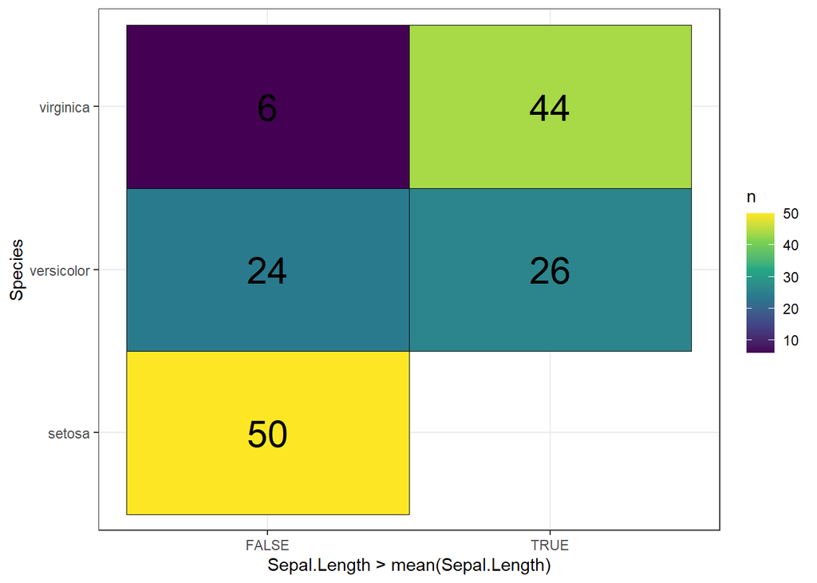

```r
iris %>%
  count(Species, Sepal.Length > mean(Sepal.Length)) %>%
  ggplot(mapping = aes(x = `Sepal.Length > mean(Sepal.Length)`,
                       y = Species)) +
  geom_tile(color = 'black',
            mapping = aes(fill = n)) +
  geom_text(mapping = aes(label = n), size = 8) +
  scale_fill_viridis_c() +
  theme_bw()
```

Lastly, map the text color to change with the number of rows.

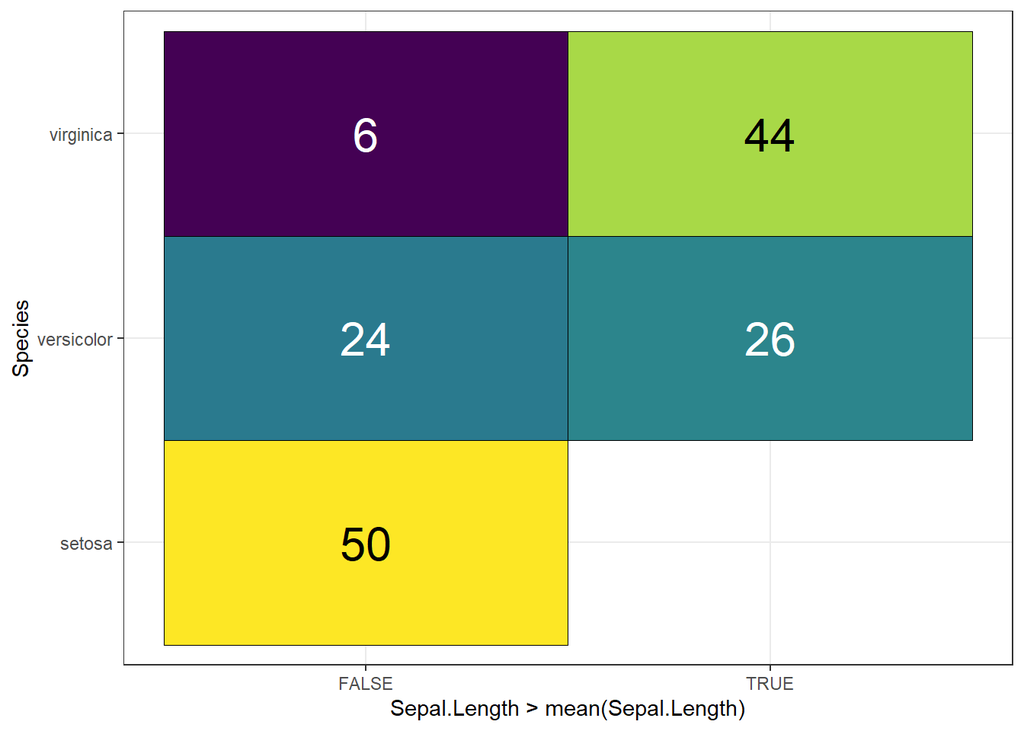

```r
iris %>%
  count(Species, Sepal.Length > mean(Sepal.Length)) %>%
  ggplot(mapping = aes(x = `Sepal.Length > mean(Sepal.Length)`,
                       y = Species)) +
  geom_tile(color = 'black',
            mapping = aes(fill = n)) +
  geom_text(mapping = aes(label = n,
                          color = n > median(n)),
            size = 8) +
  scale_fill_viridis_c(guide = FALSE) +
  scale_color_manual(guide = FALSE,
                     values = c("TRUE" = 'black',
                                "FALSE" = "white")) +
  theme_bw()
```

We could show this information with points and sizes of points.

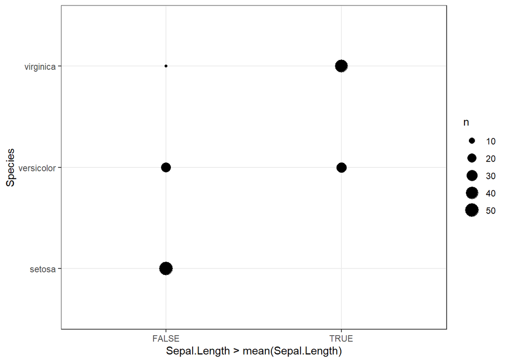

```r
iris %>%
  ggplot(mapping = aes(x = Sepal.Length > mean(Sepal.Length),
                       y = Species)) +
  geom_count() +
  theme_bw()
```